# Simultaion Exam

Author

Arshak Parsa

Published

March 2, 2025

### مقدمه

سلام پس از تلاش های فراوان بلاخره تونستم یه کاری کنم که این quarto فارسی قبول کنه :)

برای حل کردن سوال یک به نمونه ای از این توزیع ها نیاز داریم. پس اول سوال دوم را حل می کنیم.

از همین اول پارامتر ها را تعیین می کنیم.

$b=40 ,\space \mu=111$

$\alpha=35 ,\space \beta=13$

```r
b = 40
mu = 111
alpha = 35
beta = 13
```

حالا سید رو ست می کنیم

```r
set.seed(40111350013)
```

```
Error in set.seed(40111350013): supplied seed is not a valid integer
```

همونطور که میبینید ارور میده! ما می تونیم در اینجا سازش کنیم و یک عدد کوچک تر رو بدیم ولی اگر من را خوب بشناسید می دانید که من اهل سازش نیستم! باید شماره دانشجویی من رو R بپذیره!

```r
library(csvread)
set.seed(as.int64(40111350013))
```

حالا شد! اول سوال دو را حل می کنیم و با نمونه های تصادفی تولید شده در سوال دو , به حل سوال اول می پردازیم

# سوال دوم

### روش تابع توزیع

اول بیاید این دو چگالی را رسم کنیم تا یک دیدی نسبت به مسئله پیدا کنیم

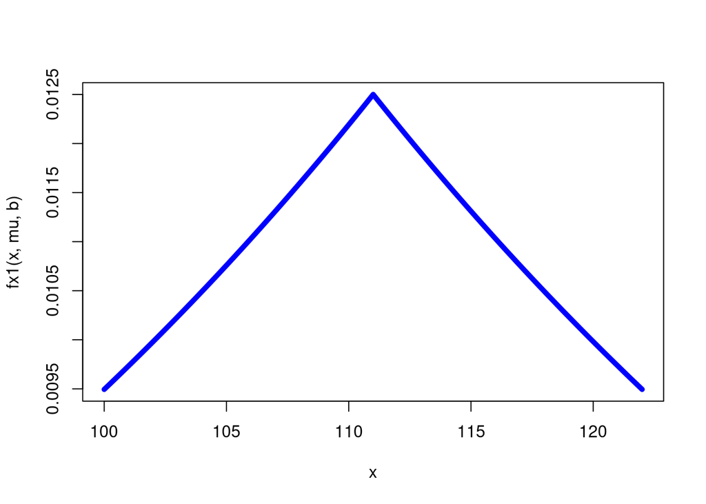

```r
fx1 = function(x,mu,b) exp(-abs(x-mu)/b)/(2*b)
fx2 = function(x,alpha,beta) (x>0)*((alpha/beta)*(x/beta)^(alpha-1)) / (1+(x/beta)^alpha)^2
curve(fx1(x,mu,b),100,122,lwd=5,col="blue")
```

این کوهه؟

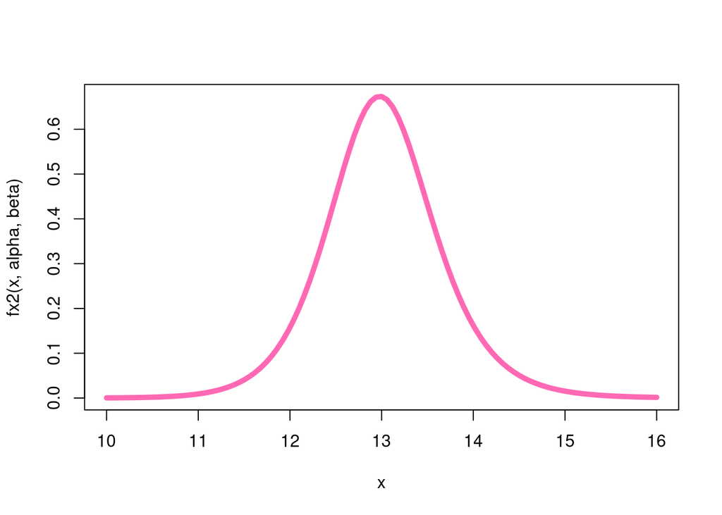

```r
curve(fx2(x,alpha,beta),10,16,lwd=5,col="hotpink")
```

این چرا انقد شبیه نرماله؟!

تابع توزیع را بیابید. برای چگالی اول زمانی که $x\le\mu$ داریم

$$F_1(x;\mu,b)=\int_{-\infty}^{x}f_1(t;\mu,b)dt = \int_{-\infty}^{x}\frac{1}{2b}exp(\frac{t-\mu}{b})dt =\frac{1}{2}(exp(\frac{x-\mu}{b})-exp(-\infty))=\frac{exp(\frac{x-\mu}{b})}{2}$$

و زمانی که $x>\mu$

$$F_1(x;\mu,b)=\int_{-\infty}^{x}f_1(t;\mu,b)dt = \int_{-\infty}^{\mu}\frac{1}{2b}exp(\frac{t-\mu}{b})dt+\int_{\mu}^{x}\frac{1}{2b}exp(\frac{\mu-t}{b})dt$$
$$=\frac{1}{2}(exp(0)-exp(-\infty)-exp(\frac{\mu-x}{b})+exp(0))=1-\frac{exp(\frac{\mu-x}{b})}{2}$$
پس به طور کلی

$$F_1(x;\mu,b)=\begin{cases}
\frac{exp(\frac{x-\mu}{b})}{2} \quad \text{if} \quad x\leq\mu\\
1-\frac{exp(\frac{\mu-x}{b})}{2} \quad \text{if} \quad x>\mu
\end{cases}$$
حالا معکوس تابع توزیع را بیابید

زمانی که $F_1^{-1}(x;\mu,b)\le\mu$

$$x=\frac{exp(\frac{F_1^{-1}(x;\mu,b)-\mu}{b})}{2} \rightarrow F_1^{-1}(x;\mu,b)= b\space ln(2x) + \mu$$
$$F_1^{-1}(x;\mu,b)= b\space ln(2x) + \mu\le\mu \rightarrow ln(2x)\le0$$
$$\rightarrow 2x\le1 \rightarrow x\le\frac{1}{2}$$

زمانی که $F_1^{-1}(x;\mu,b)>\mu$

$$x=1-\frac{exp(\frac{\mu-F_1^{-1}(x;\mu,b)}{b})}{2} \rightarrow F_1^{-1}(x;\mu,b)= \mu-b\space ln(2(1-x))$$
به طور کلی

$$F_1^{-1}(x;\mu,b)=\begin{cases}
b\space ln(2x) + \mu \quad \text{if} \quad x\leq\frac{1}{2}\\
\mu-b\space ln(2(1-x)) \quad \text{if} \quad x>\frac{1}{2}
\end{cases}$$

از اون جایی که من خیلی کنجکاو و بیکار هستم , پس از یک تحقیق کوتاه اسم این توزیع رو پیدا کردم! اسم این توزیع لاپلاس هست! توی ویکی پدیا سرچ کنید می بینید که تمامی این جواب ها درست بدست آمده

```r
Fx1 = function(x,mu,b) {
  (x<=mu)*exp((x-mu)/b)/2  + (x>mu)*(1-exp((mu-x)/b)/2 )
}
Fx1.inv = function(x,mu,b) {
  if (sum(x>1)) stop("Dadash mage ehtemal mitone bishtar az 1 bashe?")
  if (sum(x<0)) stop("Dadash mage ehtemal mitone kamtar az 0 bashe?")
  (x<=1/2)*(b*log(2*x)+mu) + (x>1/2)*(mu-b*log(2*(1-x)))
}
```

```r
#Test
Fx1.inv(Fx1(12,mu,b),mu,b)
```

```
[1] 12
```

```r
Fx1.inv(Fx1(mu,mu,b),mu,b)
```

```
[1] 111
```

```r
Fx1.inv(Fx1(156,mu,b),mu,b)
```

```
[1] 156
```

```r
# But it doesn't work for large numbers in R!
Fx1.inv(Fx1(1565,mu,b),mu,b)
```

```
[1] 1552.746
```

```r
# You can use Rmpfr
library(Rmpfr)
Fx1.inv(Fx1(mpfr(1565,128),mu,b),mu,b)
```

```
1 'mpfr' number of precision  128   bits
[1] 1565.000000000000000000000694883752641745
```

ها ها ها

من حتی توزیع دوم رو هم پیدا کردم! اسمش توزیع Dagum هست!

حالا بریم سراغ چگالی دوم

همون کارا رو میکنیم

$$F_2(x;\alpha,\beta)=\int_{0}^{x}\frac{\frac{\alpha}{\beta}(\frac{t}{\beta})^{\alpha-1}}{(1+(\frac{t}{\beta})^\alpha)^2}dt = \int_{0}^{x}\frac{\frac{\alpha{t}^{\alpha-1}}{\beta^\alpha}}{(1+(\frac{t}{\beta})^\alpha)^2}dt$$
به تغیر متغیر نیاز داریم

$$u=1+(\frac{t}{\beta})^\alpha \rightarrow du= \frac{\alpha t^{\alpha-1}}{\beta^\alpha}dt$$
$$if \quad t\rightarrow 0 \quad then \quad u\rightarrow 1$$
$$if \quad t\rightarrow x \quad then \quad u\rightarrow 1+(\frac{x}{\beta})^\alpha$$
$$F_2(x;\alpha,\beta)=\int_{1}^{1+(\frac{x}{\beta})^\alpha}\frac{1}{u^2}du=[-u^{-1}]_1^{1+(\frac{x}{\beta})^\alpha}=1-\frac{1}{1+(\frac{x}{\beta})^\alpha}$$
$$=\frac{(\frac{x}{\beta})^\alpha}{1+(\frac{x}{\beta})^\alpha}=\frac{(\frac{x}{\beta})^\alpha}{1+(\frac{x}{\beta})^\alpha}\frac{(\frac{\beta}{x})^\alpha}{(\frac{\beta}{x})^\alpha}=\frac{1}{1+(\frac{x}{\beta})^{-\alpha}}$$
به طور کلی

$$F_2(x;\alpha,\beta)=\begin{cases}
\frac{1}{1+(\frac{x}{\beta})^{-\alpha}} \quad \text{if} \quad x>0\\
0 \quad \text{if} \quad x\le0
\end{cases}$$

بخشش لازم نیست , معکوسش کنید!

$$x=\frac{1}{1+(\frac{F_2^{-1}(x;\alpha,\beta)}{\beta})^{-\alpha}} \rightarrow (\frac{F_2^{-1}(x;\alpha,\beta)}{\beta})^{-\alpha}=\frac{1}{x}-1 \rightarrow F_2^{-1}(x;\alpha,\beta)=\beta(\frac{1}{x}-1)^{-\alpha^{-1}}$$

```r
Fx2 = function(x,alpha,beta){
  (x>0)*(1/(1+(x/beta)^(-alpha)))
}
Fx2.inv = function(x,alpha,beta) {
  if (sum(x>1)) stop("Dadash mage ehtemal mitone bishtar az 1 bashe?")
  if (sum(x<0)) stop("Dadash mage ehtemal mitone kamtar az 0 bashe?")
  beta*(1/x -1)^(-1/alpha)
}

#Test
library(VGAM)
Fx2(14,alpha,beta)
```

```
[1] 0.9304601
```

```r
pdagum(14,beta,alpha,1)
```

```
[1] 0.9304601
```

```r
Fx2.inv(Fx2(6,alpha,beta),alpha,beta)
```

```
[1] 6
```

```r
Fx2.inv(0.45,alpha,beta)
```

```
[1] 12.92568
```

```r
qdagum(0.45,beta,alpha,1)
```

```
[1] 12.92568
```

وقتش شده که نمونه تصادفی تولید کنیم!

```r
rfx1 = function(n,mu,b) Fx1.inv(runif(n),mu,b)
rfx2 = function(n,alpha,beta) Fx2.inv(runif(n),alpha,beta)

samp1 = rfx1(500,mu,b);head(samp1)
```

```
[1] 174.07774  85.68157  99.18475 117.29923 178.80323  74.68335
```

```r
samp2 = rfx2(500,alpha,beta);head(samp2)
```

```
[1] 11.98657 13.08106 13.29755 13.24544 13.25437 12.95877
```

اینم نمونه هایی که قولشو دادم!

از کجا معلوم کیک نباشه؟

الان هم نمودار میکشیم هم ks.test

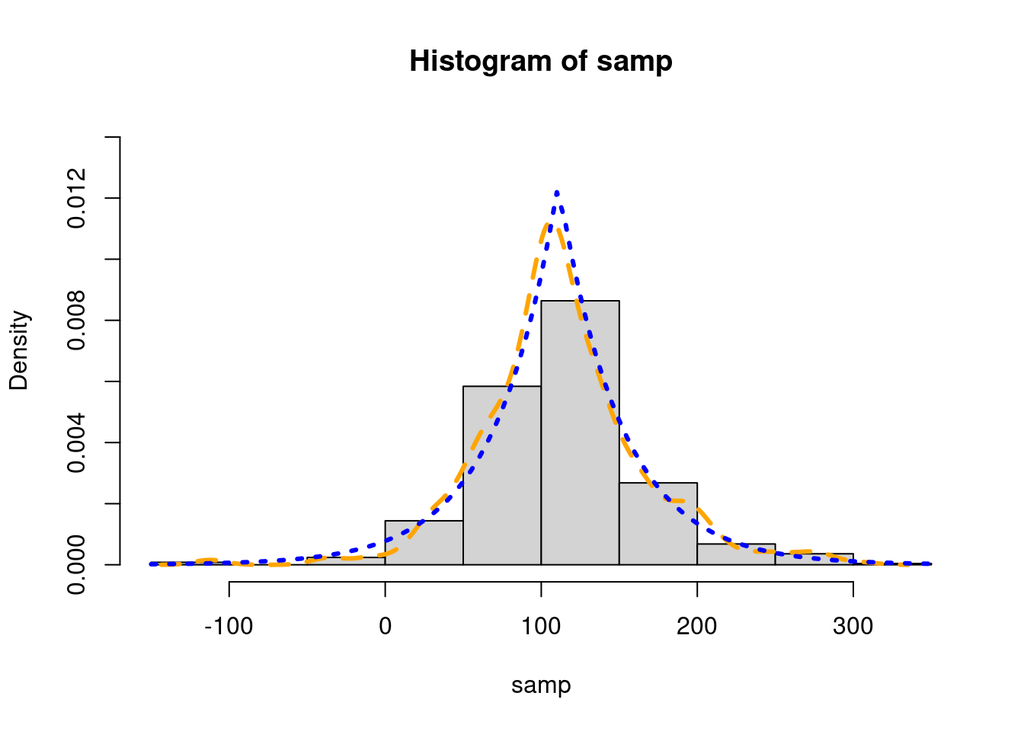

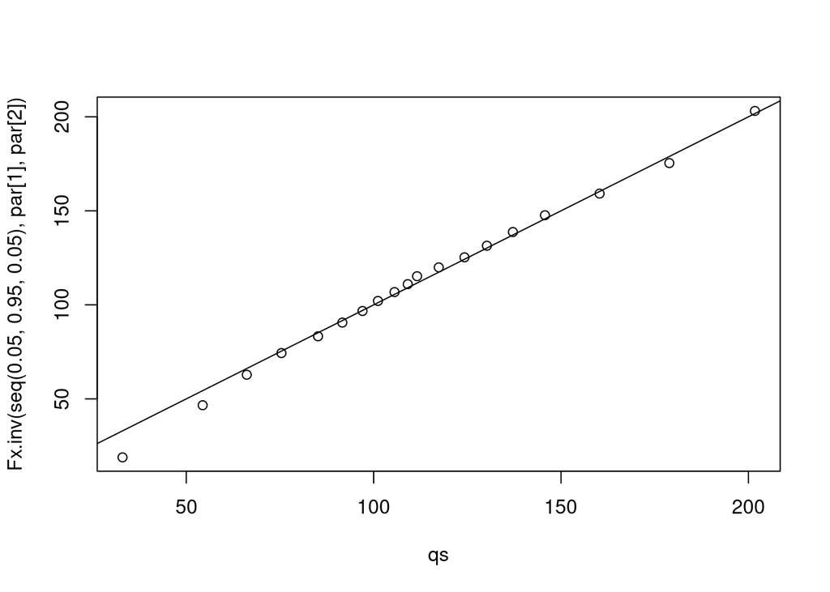

```
    Asymptotic one-sample Kolmogorov-Smirnov test

data:  samp
D = 0.049366, p-value = 0.1747
alternative hypothesis: two-sided
```

```r
check_dist = function(samp,Fx,Fx.inv,fx,ylim,par){
  hist(samp,freq = FALSE,ylim = ylim)
  lines(density(samp),col="orange",lwd=3,lty=2)
  curve(fx(x,par[1],par[2]),add = TRUE,col="blue",lwd=3,lty=3)
  qs = quantile(samp,probs=seq(0.05,0.95,0.05))
  plot(qs,Fx.inv(seq(0.05,0.95,0.05),par[1],par[2]))
  abline(0,1)
  ks.test(samp,function(x) Fx(x,par[1],par[2]))
}
check_dist(samp1,Fx1,Fx1.inv,fx1,c(0,0.014),c(mu,b))
```

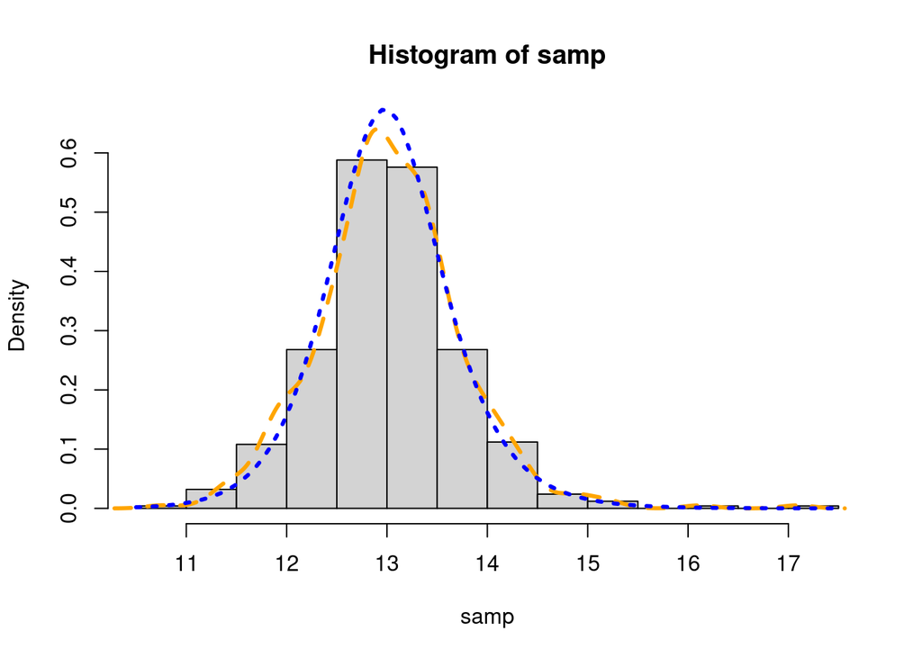

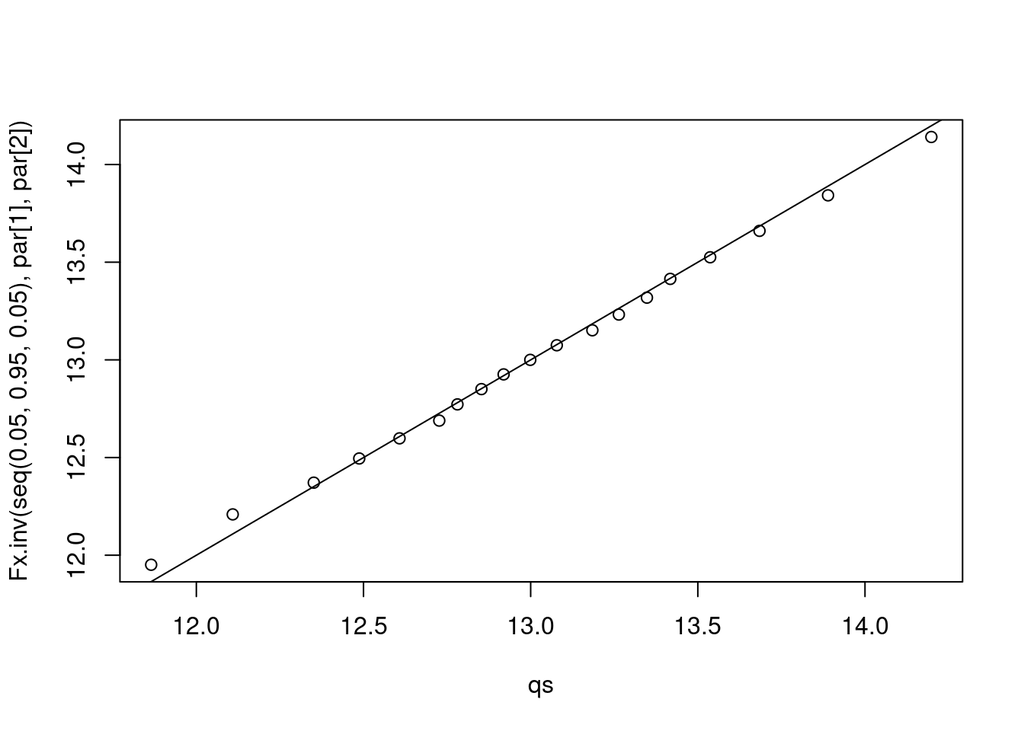

```
    Asymptotic one-sample Kolmogorov-Smirnov test

data:  samp
D = 0.025424, p-value = 0.9031
alternative hypothesis: two-sided
```

```r
check_dist(samp2,Fx2,Fx2.inv,fx2,c(0,0.65),c(alpha,beta))
```

خوبه, خدا بده برکت!

### الگوریتم رد و پذیرش

برای این الگوریتم رد و پذیرش باید یک توزیع مشخص کنیم. چه توزیعی بهتر از لاپلاس؟

```
Optimal c = 1
```

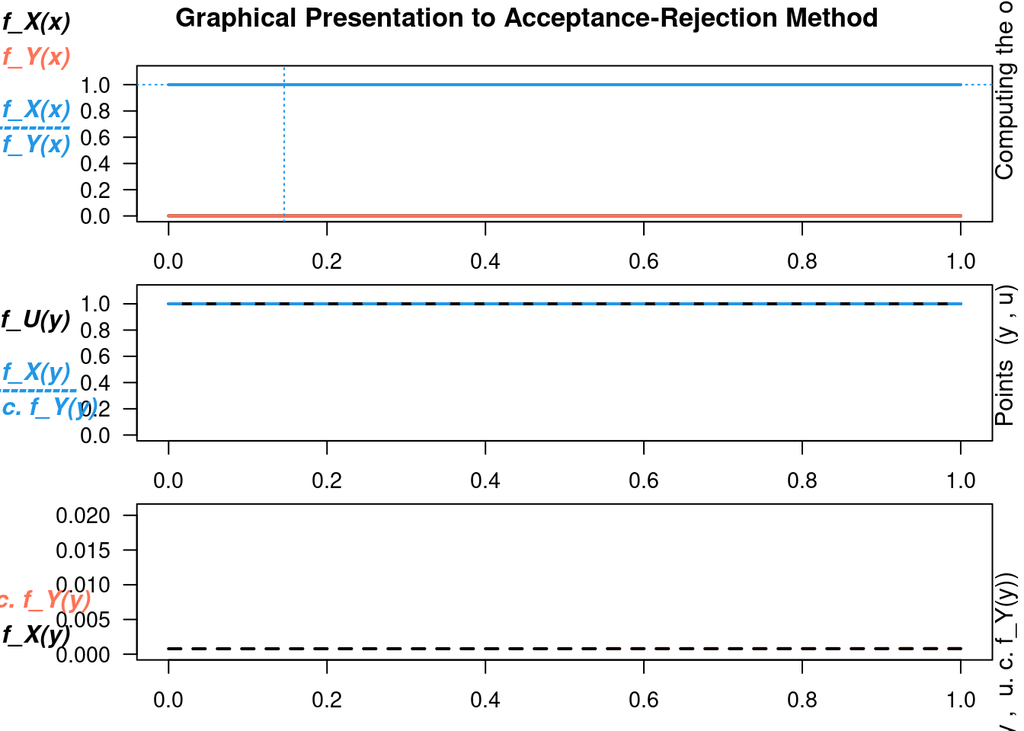

```
The numbers of Rejections = 0
Ratio of Rejections = 0
Ratio of Acceptance = 1
```

```r
library(AR)

AR.data1 = AR.Sim(200,function(x) fx1(x,mu,b),"laplace",c(mu,b))
```

```
Optimal c = 1
```

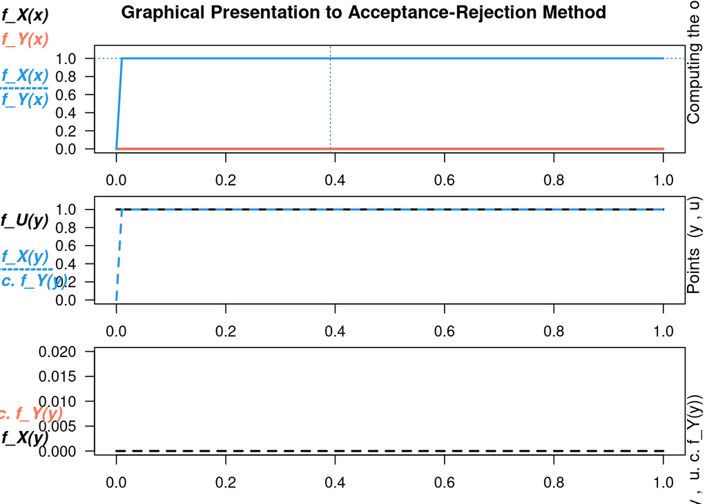

```
The numbers of Rejections = 0
Ratio of Rejections = 0
Ratio of Acceptance = 1
```

```r
AR.data2 = AR.Sim(200,function(x) fx2(x,alpha,beta),"dagum",c(beta,alpha,1))
```

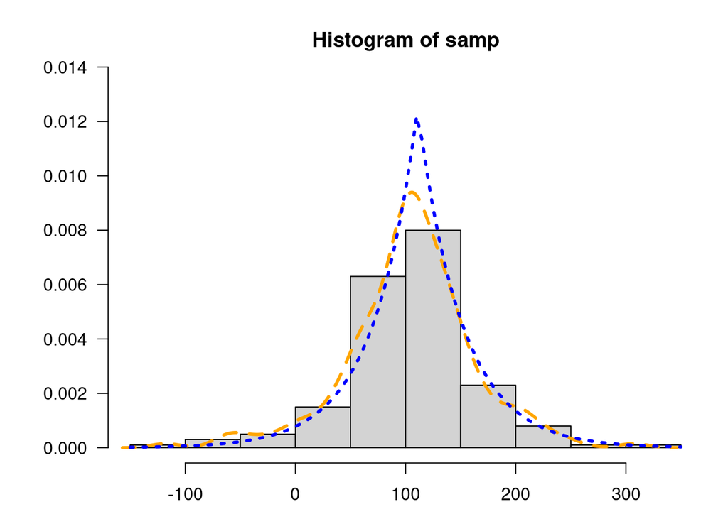

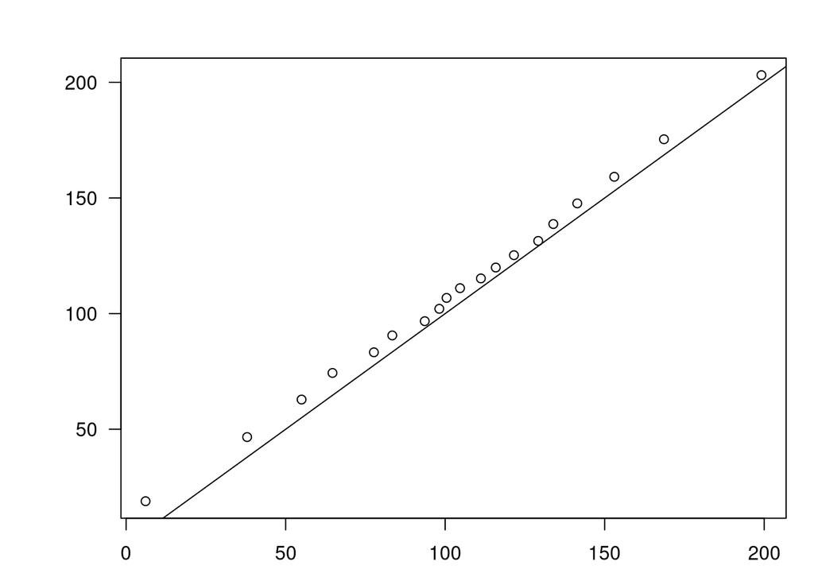

```
    Asymptotic one-sample Kolmogorov-Smirnov test

data:  samp
D = 0.088382, p-value = 0.0879
alternative hypothesis: two-sided
```

```r
check_dist(AR.data1,Fx1,Fx1.inv,fx1,c(0,0.014),c(mu,b))
```

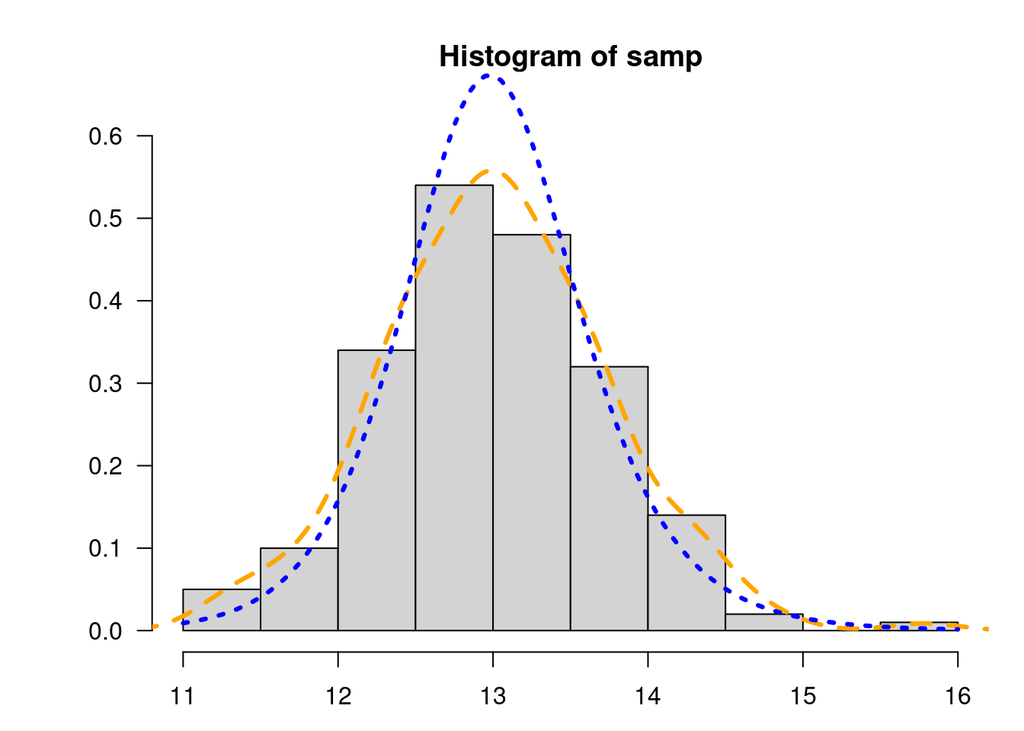

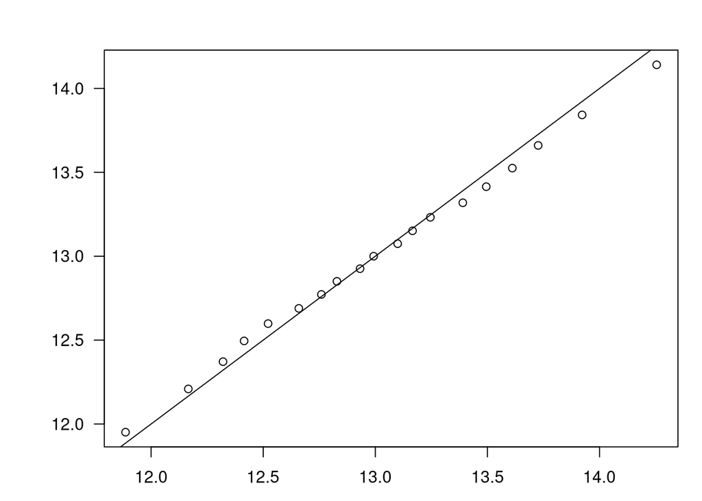

```
    Asymptotic one-sample Kolmogorov-Smirnov test

data:  samp
D = 0.054197, p-value = 0.5995
alternative hypothesis: two-sided
```

```r
check_dist(AR.data2,Fx2,Fx2.inv,fx2,c(0,0.65),c(alpha,beta))
```

اما اینطوری که مزه نمیده!

بیاید یه توزیع اشتباهی رو انتخاب کنیم حداقل چار تا ریجکت هم بگیریم.

برای لاپلاس , نرمال رو تست کردم خیلی جالب نشد , بیاید کوشی رو تست کنیم.

برای دومی هم لاپلاس در نظر میگیریم چون دم هاش حداقل کلفته تو پیدا کردن c به مشکل بر نمی خوره و بعدش میشه انقد با دو تا پارامترش بازی کرد تا بلاخره شبیه این چگالی لامصب بشه!

این الگوریتم مزخرف ترین روش هست

به دل من که نچسبید

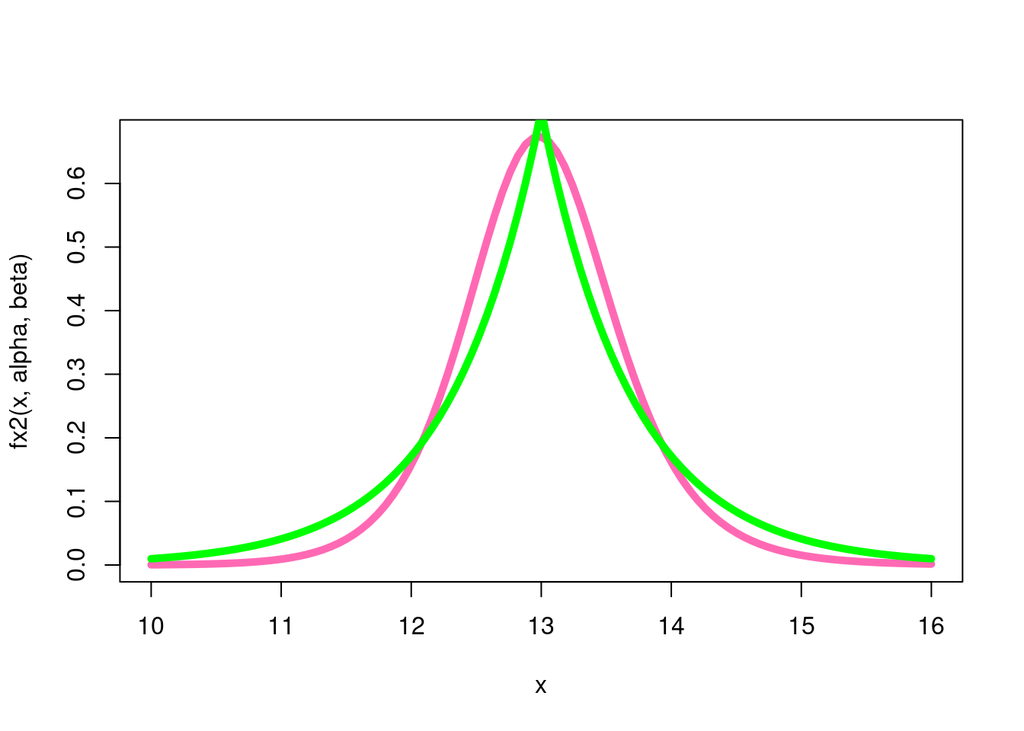

```r
# I just randomly found this!
curve(fx2(x,alpha,beta),10,16,lwd=5,col="hotpink")
curve(dlaplace(x,13,0.7),10,16,lwd=5,col="green",add=TRUE)
```

```
Optimal c = 0.86
```

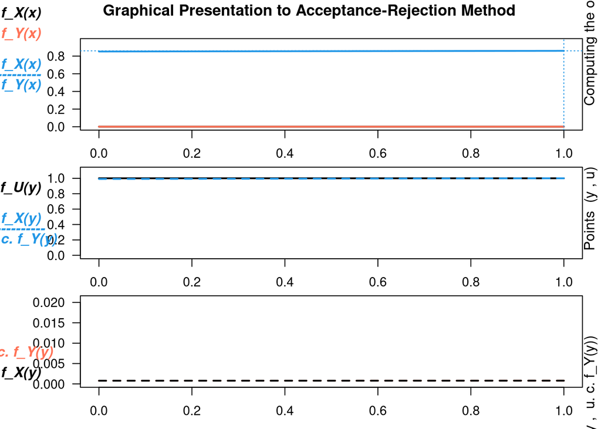

```
The numbers of Rejections = 34
Ratio of Rejections = 0.145
Ratio of Acceptance = 0.855
```

```r
AR.data1 = AR.Sim(200,function(x) fx1(x,mu,b),"cauchy",c(mu,b))
```

```
Optimal c = 0
```

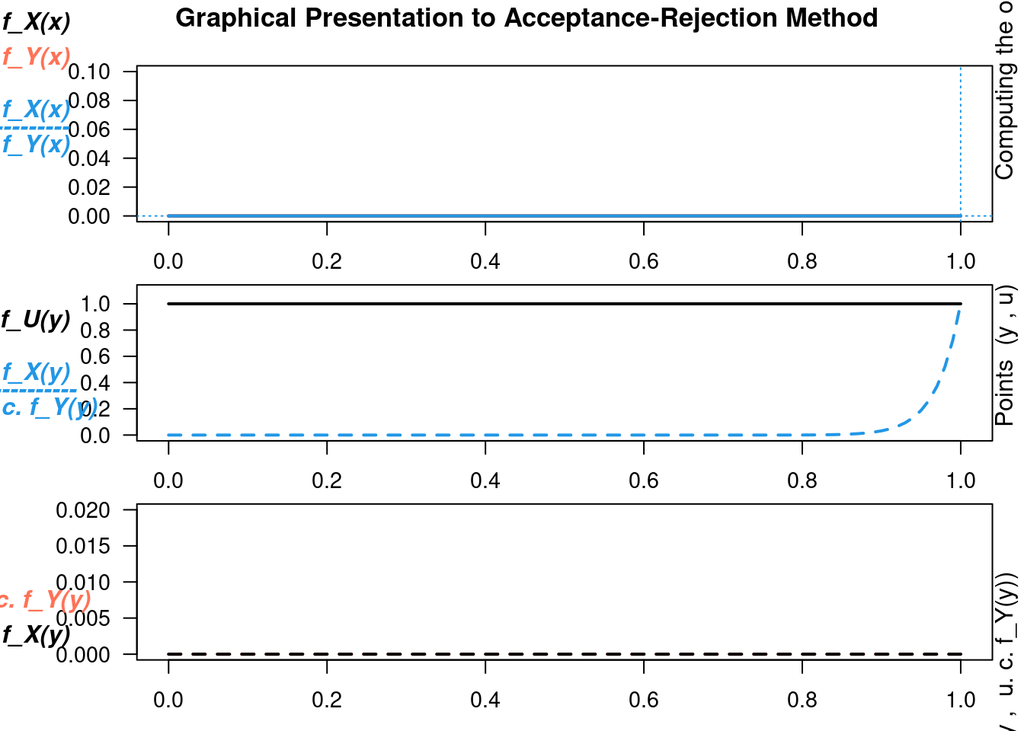

```
The numbers of Rejections = 0
Ratio of Rejections = 0
Ratio of Acceptance = 1
```

```r
AR.data2 = AR.Sim(200,function(x) fx2(x,alpha,beta),"laplace",c(13,0.7))
```

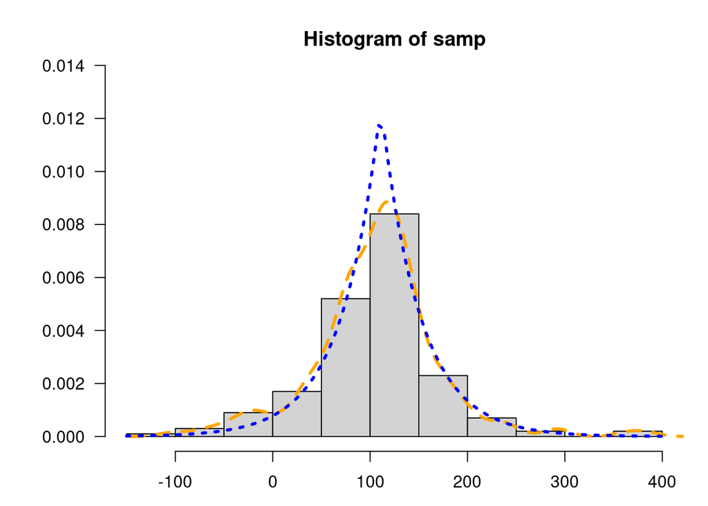

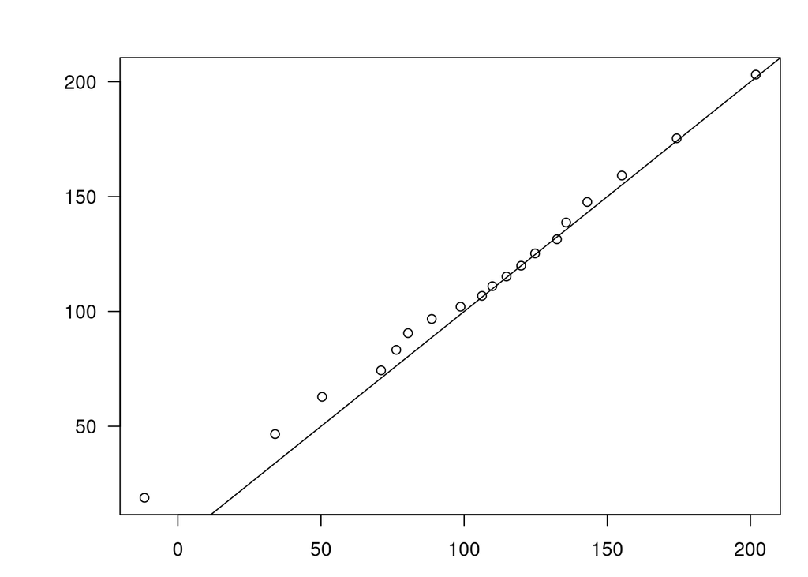

```
    Asymptotic one-sample Kolmogorov-Smirnov test

data:  samp
D = 0.080523, p-value = 0.1494
alternative hypothesis: two-sided
```

```r
check_dist(AR.data1,Fx1,Fx1.inv,fx1,c(0,0.014),c(mu,b))
```

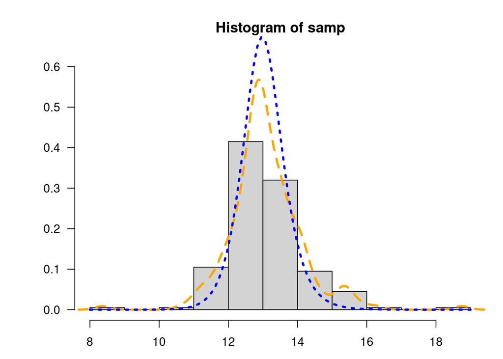

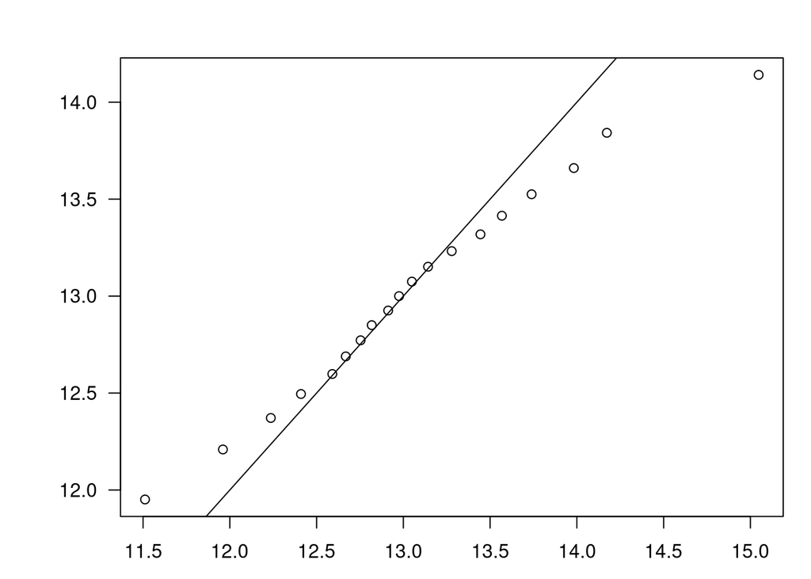

```
    Asymptotic one-sample Kolmogorov-Smirnov test

data:  samp
D = 0.093063, p-value = 0.06259
alternative hypothesis: two-sided
```

```r
check_dist(AR.data2,Fx2,Fx2.inv,fx2,c(0,0.65),c(alpha,beta))
```

# سوال اول

## روش درستنمایی بیشینه

چون توی فرمول چگالی قدر مطلق داریم فکر نکنم بتونیم مشتق بگیریم. چرا خودمون رو اذیت کنیم وقتی optim هست!

در اینجا از کتابخانه docstring برای ایجاد یکسری توضیحات استفاده می کنم.

روش بوت استرپ تا اونجا که من می دونم برای بدست اوردن توزیع برآوردگر استفاده میشه. مثلا اینجا در بدست اوردن توزیع میو هد ولی صورت سوال چنین چیزی رو نخواسته مگر اینکه توزیع رو برآورد کنی و بعد میانگین توزیع میو هد رو بگیری و اون رو به عنوان برآورد میو در نظر بگیریم که خیلی مسخره هست چون وقتی از همون اول میو هد داشتیم برای چی باید بیایم از روی برآوردگر میو یه برآورد دیگه پیدا کنیم.

```r
library(docstring)
```

```r
#New check point!
set.seed(as.int64(40111350013))

Est2.plot = function(n,fx,rfx,rpar,tpar1,tpar2){
  #' Two parameter estimate plot
  #'
  #' This function is designed for two parameter distributions.
  #' It plots MLE estimate and bootstrap together.
  #'
  #' @param rpar Real parameters
  #' @param tpar1 Test parameters for the first parameter
  #' @param tpar2 Test parameters for the second parameter
  x=rfx(n,rpar[1],rpar[2])
  Loglik = function(a) sum(log(fx(x,a[1],a[2])))
  z=0
  for (p1 in tpar1){
    for (p2 in tpar2){
      z = c(z,Loglik(c(p1,p2)))
    }
  }
  z=z[-1]
  z=matrix(z,nrow = length(tpar1), byrow = TRUE)
  persp(tpar1,tpar2,z)
  image(tpar1,tpar2,z)
  contour(tpar1,tpar2,z,add=TRUE)

  res = optim(c(rpar[1]+5,rpar[2]+5),function(x) -Loglik(x))$par
  points(res[1],res[2],col="white",pch=16)
  text(res[1],res[2]*1.01,"MLE",col="white",cex=0.8)
  points(rpar[1],rpar[2],col="green",pch=16)
  text(rpar[1],rpar[2]*.99,"Real",col="green",cex=0.8)

  #Bootstrap
  # I DO NOT THINK WETHER THIS METHOD IS APPROPIATE!

}
?Est2.plot
```

```
No documentation for 'Est2.plot' in specified packages and libraries:
you could try '??Est2.plot'
```

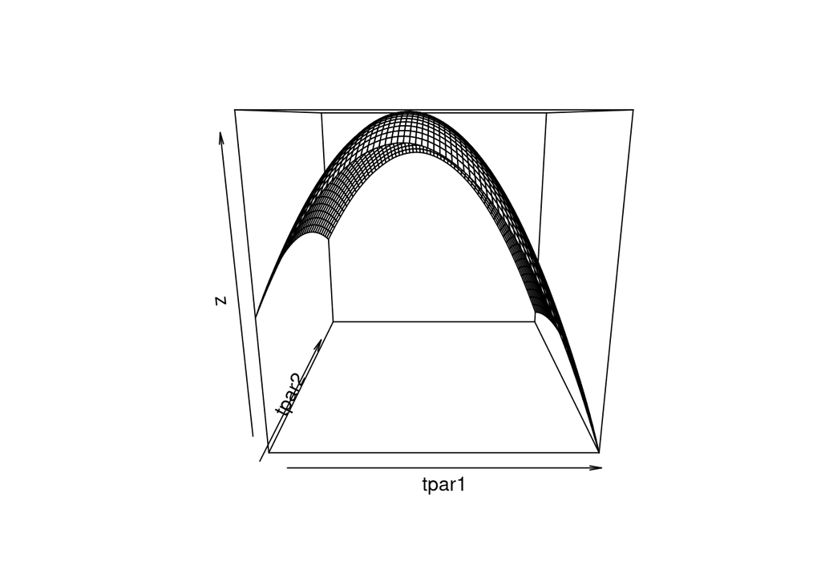

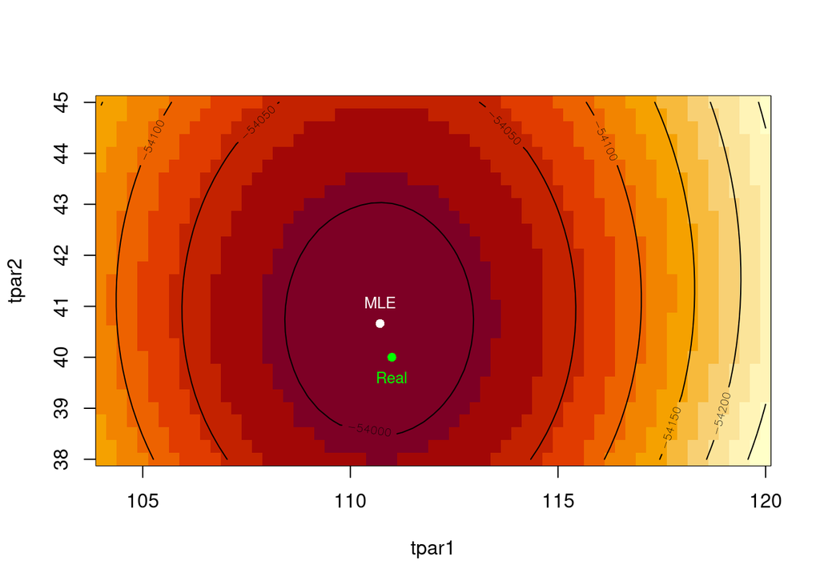

```r
Est2.plot(10000,fx1,rfx1,c(mu,b),seq(104,120,0.25),seq(38,45,0.25))
```

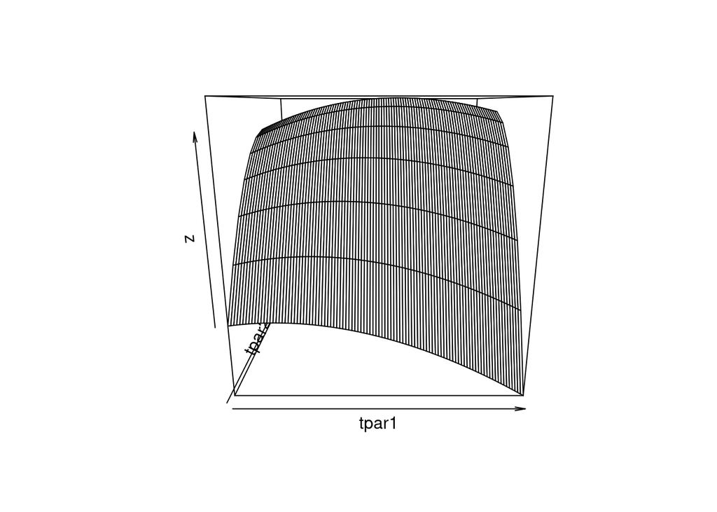

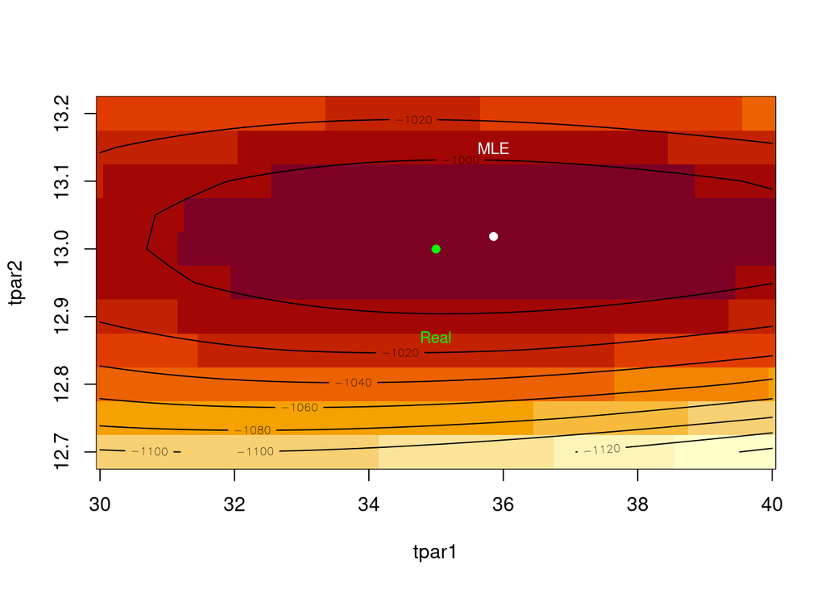

```r
Est2.plot(1000,fx2,rfx2,c(alpha,beta),seq(30,40,0.1),seq(12.7,13.2,0.05))
```

بیاید چک کنیم آیا MLE به یارش میرسه یا نه!

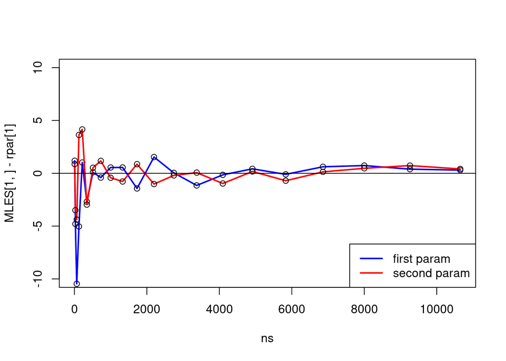

```r
# first density
MLE_conv = function(fx,rfx,rpar){
  MLES = matrix(0,2)
  Loglik = function(a) sum(log(fx(x,a[1],a[2])))
  ns = (2:22)^3
  for (n in ns){
    x=rfx(n,rpar[1],rpar[2])
    res = optim(c(rpar[1]+5,rpar[2]+5),function(x) -Loglik(x))$par
    MLES = cbind(MLES,res)
  }
  MLES = MLES[,-1]
  plot(ns,MLES[1,]-rpar[1],ylim=c(-10,10),type="l",lwd=2,col="blue")
  points(ns,MLES[1,]-rpar[1])
  lines(ns,MLES[2,]-rpar[2],type="l",lwd=2,col="red")
  points(ns,MLES[2,]-rpar[2])
  abline(h=0)
  legend("bottomright",c("first param","second param"),col=c("blue","red"),lwd=2)
}
MLE_conv(fx1,rfx1,c(mu,b))
```

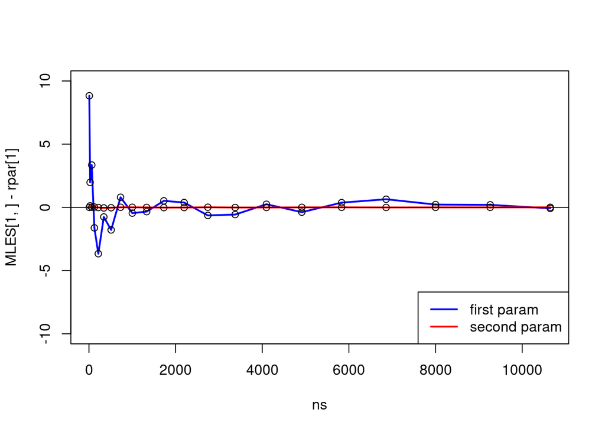

```r
MLE_conv(fx2,rfx2,c(alpha,beta))
```

# سوال سوم

## ریمان

قبل از این که این کار را به طور دستی انجام دهیم , بیاید یدور integrate رو تست کنیم

```r
integrate(function(x) exp(-x^6)/(1+x^2),0,Inf)
```

```
0.7391529 with absolute error < 5e-08
```

خب پس جواب باید این بشه

از اون جایی که من خیلی حال ندارم همون کد های شما رو کپی پیست می کنم :)

```r
# b---> infinity
a=0
b=1.5
# even 1.5 is enough
n=15

w<-(b-a)/n

ksi<-seq(a+w/2,b-w/2,length=n)

h<-exp(-ksi^6)/(1+ksi^2)

s<-sum(h*w)
s
```

```
[1] 0.7391529
```

[figure not shown]

```r
curve(exp(-x^6)/(1+x^2),0,b,lwd=2)
#curve(dnorm(x,40,10),0,m,add=TRUE,col=2,lwd=3)
abline(v=c(a,b),lty=2,lwd=3,col=2)

rect(ksi-w/2,0,ksi+w/2,h,col = "#ff7700aa")
segments(ksi-w/2,h,ksi+w/2,h,lwd=2)
segments(ksi,0,ksi,h,lwd=2)
```

## مونت کارلو

برای روش مونت کارلو نیاز به یک توزیع داریم. چون این انتگرال از 1.5 به بعد خیلی مقدار نداره از همون توزیع یکنواخت 0 و 1.5 استفاده می کنیم.

این روش تا اونجا که می دونم به خاطر قانون اعداد بزرگ برقرار است.

```r
U = runif(200000,0,1.5)

1.5*mean(exp(-U^6)/(1+U^2))
```

```
[1] 0.7396436
```

# سخن پایانی

این فایل توسط یک انسان نوشته شده. جهت جلوگیری از هر گونه کاهش کیفیت از استفاده کردن از هر گونه هوش مصنوعی خودداری شده.